# ggplot2 Elegant Graphics for Data Analysis

홍우헌

quasar103@naver.com

2018-06-27

# 1 Chapter 9

> Data Analysis

시작하기 전에, 8장을 복습하겠다.

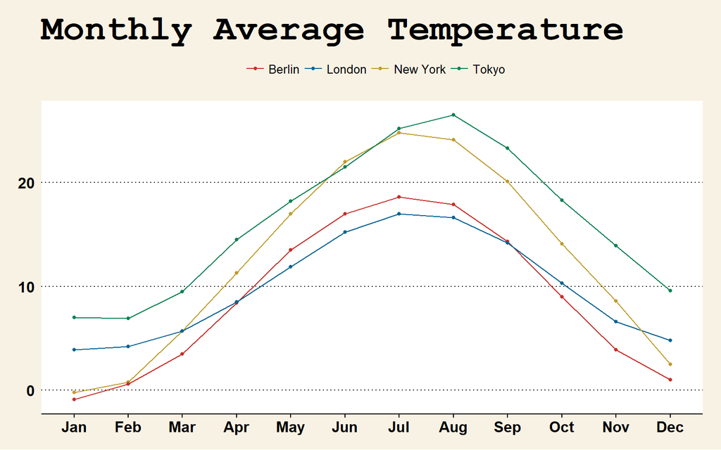

```r
dtemp <- data_frame(
  months = factor(rep(substr(month.name, 1, 3), 4),
                  levels = substr(month.name, 1, 3)),
                    city = rep(c("Tokyo", "New York", "Berlin", "London"), each = 12),
                    temp = c(7.0, 6.9, 9.5, 14.5, 18.2, 21.5, 25.2, 26.5, 23.3, 18.3, 13.9, 9.6,
                             -0.2, 0.8, 5.7, 11.3, 17.0, 22.0, 24.8, 24.1, 20.1, 14.1, 8.6, 2.5,
                             -0.9, 0.6, 3.5, 8.4, 13.5, 17.0, 18.6, 17.9, 14.3, 9.0, 3.9, 1.0,
                             3.9, 4.2, 5.7, 8.5, 11.9, 15.2, 17.0, 16.6, 14.2, 10.3, 6.6, 4.8))

ggplot(dtemp, aes(x = months, y = temp, group = city, color = city)) +
    geom_line() +
    geom_point(size = 1.1) +
    ggtitle("Monthly Average Temperature") +
    theme_wsj() +
    theme(panel.background = element_rect(fill = "white")) +
    scale_color_wsj("colors6", "")
```

`substr(month.name, 1, 3)` 과 `month.abb`는 동일하다.

Tidy Data란?

1. Each variable must have its own column.
2. Each observation must have its own row.
3. Each value must have its own cell.

```r
ec2 <- read_csv(file.choose())
```

- 월은 열에 저장한다.
- 년은 열의 이름에 분산시킨다
- rate은 각 셀의 값이다

두 가지 중요한 도구가 있다. - Spread & gather - Separate & unite

# 2 Spread and Gather

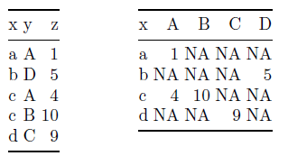

첫번째 형태를 indexted data, 두번째 형태를 Cartesian data라고 부른다. 두가지 형태 모두 “A”, “B”, “C”, “D”가 의미하는 바에 따라 tidy가 될 수 있다. 또한 결측값은 한가지 형태에는 명백하지만 다른 형태에서는 암시적이다. NA는 presence of absence이지만 때때로 absence of presence일 수 있다.

## 2.1 Gather

- data : 바꾸고자 하는 데이터 셋
- key & value : key는 열의 이름으로부터 만들어지는 변수의 이름이고 value는 셀값으로부터 만들어지는 변수의 이름이다.
- … : A,B,C,D나 A:D로 명시할 수 있다. gather하지 않으려면 -E, -F와 같이 명시한다.

```r
gather(ec2, key = year, value = unemp, `2006`:`2015`)
```

```
## # A tibble: 120 x 3
##    month year  unemp
##    <int> <chr> <dbl>
##  1     1 2006    8.6
##  2     2 2006    9.1
##  3     3 2006    8.7
##  4     4 2006    8.4
##  5     5 2006    8.5
##  6     6 2006    7.3
##  7     7 2006    8
##  8     8 2006    8.4
##  9     9 2006    8
## 10    10 2006    7.9
## # ... with 110 more rows
```

```r
gather(ec2, key = year, value = unemp, -month)
```

```
## # A tibble: 120 x 3
##    month year  unemp
##    <int> <chr> <dbl>
##  1     1 2006    8.6
##  2     2 2006    9.1
##  3     3 2006    8.7
##  4     4 2006    8.4
##  5     5 2006    8.5
##  6     6 2006    7.3
##  7     7 2006    8
##  8     8 2006    8.4
##  9     9 2006    8
## 10    10 2006    7.9
## # ... with 110 more rows
```

```r
economics_2 <- gather(ec2, year, rate, `2006`:`2015`, convert = TRUE, na.rm = TRUE)
```

`convert = TRUE`를 사용하면 year를 문자열에서 숫자로 바꿔준다. `na.rm = TRUE`는 데이터가 없는 월을 제거해준다.

장기간이나 계절적 변동을 강조할 수 있다.

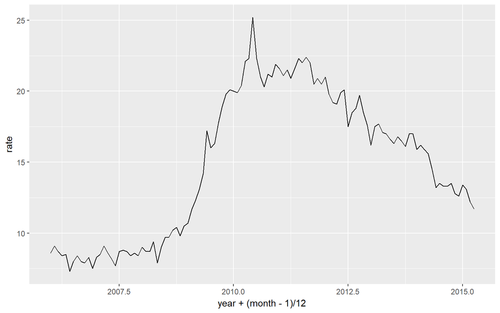

```r
ggplot(economics_2, aes(year + (month - 1) / 12, rate)) +
  geom_line()
```

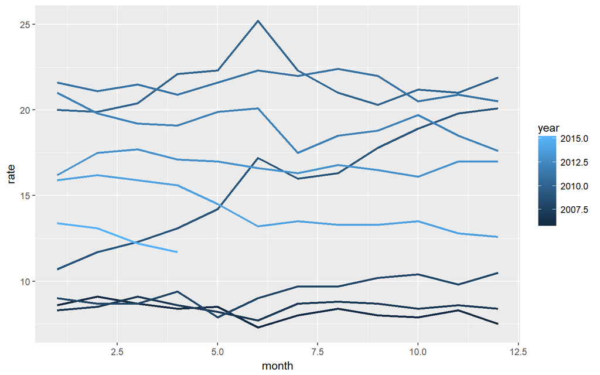

```r
ggplot(economics_2, aes(month, rate, group = year)) +
  geom_line(aes(colour = year), size = 1)
```

## 2.2 Spread

```r
weather <- data_frame(
  day = rep(1:3, 2),
  obs = rep(c("temp", "rain"), each = 3),
  val = c(c(23, 22, 20), c(0, 0, 5))
)
weather
```

```
## # A tibble: 6 x 3
##     day obs     val
##   <int> <chr> <dbl>
## 1     1 temp     23
## 2     2 temp     22
## 3     3 temp     20
## 4     1 rain      0
## 5     2 rain      0
## 6     3 rain      5
```

Spread는 이런 지저분한 indexed form을 tidy Cartesian형태로 바꿔준다.

```r
spread(weather, key = obs, value = val)
```

```
## # A tibble: 3 x 3
##     day  rain  temp
##   <int> <dbl> <dbl>
## 1     1     0    23
## 2     2     0    22
## 3     3     5    20
```

## 2.3 Exercises

1. How can you convert back and forth between the economics and economics long datasets built into ggplot2?

```r
gather(economics, key = variable, value = value, -date)
```

```
## # A tibble: 2,870 x 3
##    date       variable value
##    <date>     <chr>    <dbl>
##  1 1967-07-01 pce       507.
##  2 1967-08-01 pce       510.
##  3 1967-09-01 pce       516.
##  4 1967-10-01 pce       513.
##  5 1967-11-01 pce       518.
##  6 1967-12-01 pce       526.
##  7 1968-01-01 pce       532.
##  8 1968-02-01 pce       534.
##  9 1968-03-01 pce       545.
## 10 1968-04-01 pce       545.
## # ... with 2,860 more rows
```

```r
economics_long
```

```
## # A tibble: 2,870 x 4
## # Groups:   variable [5]
##    date       variable value  value01
##    <date>     <fct>    <dbl>    <dbl>
##  1 1967-07-01 pce       507. 0
##  2 1967-08-01 pce       510. 0.000266
##  3 1967-09-01 pce       516. 0.000764
##  4 1967-10-01 pce       513. 0.000472
##  5 1967-11-01 pce       518. 0.000918
##  6 1967-12-01 pce       526. 0.00158
##  7 1968-01-01 pce       532. 0.00207
##  8 1968-02-01 pce       534. 0.00230
##  9 1968-03-01 pce       545. 0.00322
## 10 1968-04-01 pce       545. 0.00319
## # ... with 2,860 more rows
```

2. Install the EDAWR package from https://github.com/rstudio/EDAWR. Tidy the storms, population and tb datasets.

https://www.gis-blog.com/data-management-with-r-tidyr-part-1/ 를 참고하라

```r
# devtools::install_github("rstudio/EDAWR")
library(EDAWR)
storms
```

```
## # tibble [6 x 4]
##   storm    wind pressure date
##   <chr>   <int>    <int> <date>
## 1 Alberto   110     1007 2000-08-03
## 2 Alex       45     1009 1998-07-27
## 3 Allison    65     1005 1995-06-03
## 4 Ana        40     1013 1997-06-30
## 5 Arlene     50     1010 1999-06-11
## 6 Arthur     45     1010 1996-06-17
```

```r
cases # tidy data가 아니다
```

```
##   country  2011  2012  2013
## 1      FR  7000  6900  7000
## 2      DE  5800  6000  6200
## 3      US 15000 14000 13000
```

```r
gather(cases, key = year, value = value, -country)
```

```
##   country year value
## 1      FR 2011  7000
## 2      DE 2011  5800
## 3      US 2011 15000
## 4      FR 2012  6900
## 5      DE 2012  6000
## 6      US 2012 14000
## 7      FR 2013  7000
## 8      DE 2013  6200
## 9      US 2013 13000
```

```r
pollution
```

```
##       city  size amount
## 1 New York large     23
## 2 New York small     14
## 3   London large     22
## 4   London small     16
## 5  Beijing large    121
## 6  Beijing small     56
```

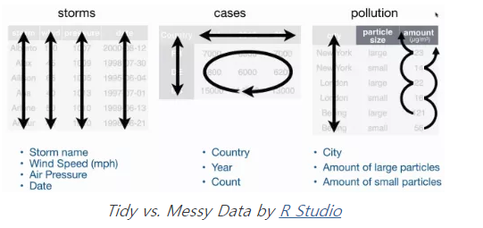

# 3 Advantages of tidy data

storm 이름과 압력을 추출하기 위해 간단히 `storms$storm`, `storms$pressure`를 입력하면 된다.

두번째 예시는 “untidy”인 pollution dataset이다. 도시의 이름을 추출하거나 큰 입자의 양을 추출하기 위해서는 `pollution$city[1,3,5]` `pollution$amount[2,4,6]`과 같이 지저분하고 복잡한 코드를 입력해야한다. 데이터가 커지면 더 복잡해질 것이다.

```r
spread(pollution, key = size, value = amount)
```

```
##       city large small
## 1  Beijing   121    56
## 2   London    22    16
## 3 New York    23    14
```

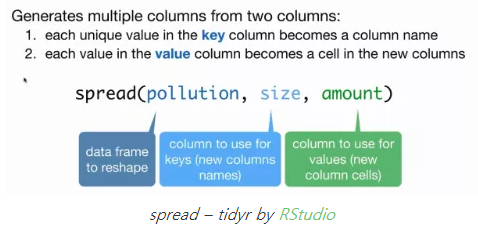

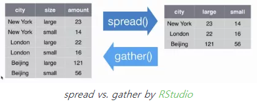

## 3.1 separate & unite

`separate()`는 하나의 열을 다수의 열로 나눌 때 이용 create new df with 3 new columns “year”, “month”, “day” out of the initial “date column

```r
storms.sep <- separate(storms, date, c("year", "month", "day"), sep = "-")
```

`unite()`는 다수의 열을 하나의 열로 합칠 때 이용

```r
unite(storms.sep, "date", 4:6, sep = "-")
```

```
## # A tibble: 6 x 4
##   storm    wind pressure date
##   <chr>   <int>    <int> <chr>
## 1 Alberto   110     1007 2000-08-03
## 2 Alex       45     1009 1998-07-27
## 3 Allison    65     1005 1995-06-03
## 4 Ana        40     1013 1997-06-30
## 5 Arlene     50     1010 1999-06-11
## 6 Arthur     45     1010 1996-06-17
```

# 4 Separate and Unite

Spread와 gather이 변수가 잘못된 장소에 위치해 있을 때 도움을 준다면 Separate와 unite는 다수의 변수가 하나의 열로 쑤셔 넣거나 다수의 열로 분산시킬때 사용한다.

```r
trt <- data_frame(
  var = paste0(rep(c("beg", "end"), each = 3), "_", rep(c("a", "b", "c"))),
  val = c(1, 4, 2, 10, 5, 11)
)
trt
```

```
## # A tibble: 6 x 2
##   var     val
##   <chr> <dbl>
## 1 beg_a     1
## 2 beg_b     4
## 3 beg_c     2
## 4 end_a    10
## 5 end_b     5
## 6 end_c    11
```

4개의 인자가 있다.

- data : 데이터프레임
- col : 나눌 변수의 이름
- into : 새 변수의 이름(문자벡터)
- sep : 변수를 어떻게 나눌 것인지에 대한 설명. 정규표현식도 가능하다.

```r
separate(trt, var, c("time", "treatment"), "_")
```

```
## # A tibble: 6 x 3
##   time  treatment   val
##   <chr> <chr>     <dbl>
## 1 beg   a             1
## 2 beg   b             4
## 3 beg   c             2
## 4 end   a            10
## 5 end   b             5
## 6 end   c            11
```

`extract(data, col, into, regex = "([[:alnum:]]+)", remove = TRUE, convert = FALSE, ...)`

## 4.1 Exercises

1. Install the EDAWR package from https://github.com/rstudio/EDAWR. Tidy the who dataset.

```r
data(package = "EDAWR", who)
car::some(who) # WHO의 1995~2013 폐결핵(tuberculosis)데이터
```

```
## # A tibble: 10 x 60
##    country           iso2  iso3   year new_sp_m014 new_sp_m1524 new_sp_m2534
##    <chr>             <chr> <chr> <int>       <int>        <int>        <int>
##  1 Belarus           BY    BLR    2007          NA           57          142
##  2 Brazil            BR    BRA    1999         301         3662         5401
##  3 Cambodia          KH    KHM    1982          NA           NA           NA
##  4 Cayman Islands    KY    CYM    1990          NA           NA           NA
##  5 Guatemala         GT    GTM    1981          NA           NA           NA
##  6 Lao People's Dem~ LA    LAO    1993          NA           NA           NA
##  7 Nauru             NR    NRU    2002          NA           NA            1
##  8 Republic of Korea KR    KOR    1985          NA           NA           NA
##  9 Sierra Leone      SL    SLE    1980          NA           NA           NA
## 10 The Former Yugos~ MK    MKD    1991          NA           NA           NA
## # ... with 53 more variables: new_sp_m3544 <int>, new_sp_m4554 <int>,
## #   new_sp_m5564 <int>, new_sp_m65 <int>, new_sp_f014 <int>,
## #   new_sp_f1524 <int>, new_sp_f2534 <int>, new_sp_f3544 <int>,
## #   new_sp_f4554 <int>, new_sp_f5564 <int>, new_sp_f65 <int>,
## #   new_sn_m014 <int>, new_sn_m1524 <int>, new_sn_m2534 <int>,
## #   new_sn_m3544 <int>, new_sn_m4554 <int>, new_sn_m5564 <int>,
## #   new_sn_m65 <int>, new_sn_f014 <int>, new_sn_f1524 <int>,
## #   new_sn_f2534 <int>, new_sn_f3544 <int>, new_sn_f4554 <int>,
## #   new_sn_f5564 <int>, new_sn_f65 <int>, new_ep_m014 <int>,
## #   new_ep_m1524 <int>, new_ep_m2534 <int>, new_ep_m3544 <int>,
## #   new_ep_m4554 <int>, new_ep_m5564 <int>, new_ep_m65 <int>,
## #   new_ep_f014 <int>, new_ep_f1524 <int>, new_ep_f2534 <int>,
## #   new_ep_f3544 <int>, new_ep_f4554 <int>, new_ep_f5564 <int>,
## #   new_ep_f65 <int>, new_rel_m014 <int>, new_rel_m1524 <int>,
## #   new_rel_m2534 <int>, new_rel_m3544 <int>, new_rel_m4554 <int>,
## #   new_rel_m5564 <int>, new_rel_m65 <int>, new_rel_f014 <int>,
## #   new_rel_f1524 <int>, new_rel_f2534 <int>, new_rel_f3544 <int>,
## #   new_rel_f4554 <int>, new_rel_f5564 <int>, new_rel_f65 <int>
```

첫번째 3세글자는 TB의 new or old

두번째 두 글자는

- rel stands for cases of relapse(재발)
- ep stands for cases of extrapulmonary(폐의 바깥) TB
- sn stands for cases of pulmonary(폐의) TB that could not be diagnosed by a pulmonary smear (smear negative)
- sp stands for cases of pulmonary TB that could be diagnosed be a pulmonary smear (smear positive)

6번째 글자는 TB환자의 성별 f or m

나머지 숫자들은 TB환자의 연령대 014 : 0 ~14, 1424 : 15~24 etc.

```r
who2 <- who
(who2 <- gather(who2, "code", "value", 5:60))
```

```
## # A tibble: 405,440 x 6
##    country     iso2  iso3   year code        value
##    <chr>       <chr> <chr> <int> <chr>       <int>
##  1 Afghanistan AF    AFG    1980 new_sp_m014    NA
##  2 Afghanistan AF    AFG    1981 new_sp_m014    NA
##  3 Afghanistan AF    AFG    1982 new_sp_m014    NA
##  4 Afghanistan AF    AFG    1983 new_sp_m014    NA
##  5 Afghanistan AF    AFG    1984 new_sp_m014    NA
##  6 Afghanistan AF    AFG    1985 new_sp_m014    NA
##  7 Afghanistan AF    AFG    1986 new_sp_m014    NA
##  8 Afghanistan AF    AFG    1987 new_sp_m014    NA
##  9 Afghanistan AF    AFG    1988 new_sp_m014    NA
## 10 Afghanistan AF    AFG    1989 new_sp_m014    NA
## # ... with 405,430 more rows
```

```r
(who2 <- separate(who2, code, c("new", "var", "sexage")))
```

```
## # A tibble: 405,440 x 8
##    country     iso2  iso3   year new   var   sexage value
##    <chr>       <chr> <chr> <int> <chr> <chr> <chr>  <int>
##  1 Afghanistan AF    AFG    1980 new   sp    m014      NA
##  2 Afghanistan AF    AFG    1981 new   sp    m014      NA
##  3 Afghanistan AF    AFG    1982 new   sp    m014      NA
##  4 Afghanistan AF    AFG    1983 new   sp    m014      NA
##  5 Afghanistan AF    AFG    1984 new   sp    m014      NA
##  6 Afghanistan AF    AFG    1985 new   sp    m014      NA
##  7 Afghanistan AF    AFG    1986 new   sp    m014      NA
##  8 Afghanistan AF    AFG    1987 new   sp    m014      NA
##  9 Afghanistan AF    AFG    1988 new   sp    m014      NA
## 10 Afghanistan AF    AFG    1989 new   sp    m014      NA
## # ... with 405,430 more rows
```

```r
(who2 <- separate(who2, sexage, c("sex", "age"), sep = 1)) # sep = 1 기억
```

```
## # A tibble: 405,440 x 9
##    country     iso2  iso3   year new   var   sex   age   value
##    <chr>       <chr> <chr> <int> <chr> <chr> <chr> <chr> <int>
##  1 Afghanistan AF    AFG    1980 new   sp    m     014      NA
##  2 Afghanistan AF    AFG    1981 new   sp    m     014      NA
##  3 Afghanistan AF    AFG    1982 new   sp    m     014      NA
##  4 Afghanistan AF    AFG    1983 new   sp    m     014      NA
##  5 Afghanistan AF    AFG    1984 new   sp    m     014      NA
##  6 Afghanistan AF    AFG    1985 new   sp    m     014      NA
##  7 Afghanistan AF    AFG    1986 new   sp    m     014      NA
##  8 Afghanistan AF    AFG    1987 new   sp    m     014      NA
##  9 Afghanistan AF    AFG    1988 new   sp    m     014      NA
## 10 Afghanistan AF    AFG    1989 new   sp    m     014      NA
## # ... with 405,430 more rows
```

```r
(who2 <- spread(who2, var, value))
```

```
## # A tibble: 101,360 x 11
##    country     iso2  iso3   year new   sex   age      ep   rel    sn    sp
##    <chr>       <chr> <chr> <int> <chr> <chr> <chr> <int> <int> <int> <int>
##  1 Afghanistan AF    AFG    1980 new   m     014      NA    NA    NA    NA
##  2 Afghanistan AF    AFG    1981 new   m     014      NA    NA    NA    NA
##  3 Afghanistan AF    AFG    1982 new   m     014      NA    NA    NA    NA
##  4 Afghanistan AF    AFG    1983 new   m     014      NA    NA    NA    NA
##  5 Afghanistan AF    AFG    1984 new   m     014      NA    NA    NA    NA
##  6 Afghanistan AF    AFG    1985 new   m     014      NA    NA    NA    NA
##  7 Afghanistan AF    AFG    1986 new   m     014      NA    NA    NA    NA
##  8 Afghanistan AF    AFG    1987 new   m     014      NA    NA    NA    NA
##  9 Afghanistan AF    AFG    1988 new   m     014      NA    NA    NA    NA
## 10 Afghanistan AF    AFG    1989 new   m     014      NA    NA    NA    NA
## # ... with 101,350 more rows
```

2. Work through the demos included in the tidyr package (demo(package = “tidyr”))

```r
grades <- tbl_df(read.table(header = TRUE, text = "
   ID   Test Year   Fall Spring Winter
    1   1   2008    15      16      19
    1   1   2009    12      13      27
    1   2   2008    22      22      24
    1   2   2009    10      14      20
    2   1   2008    12      13      25
    2   1   2009    16      14      21
    2   2   2008    13      11      29
    2   2   2009    23      20      26
    3   1   2008    11      12      22
    3   1   2009    13      11      27
    3   2   2008    17      12      23
    3   2   2009    14      9       31
   "))

grades %>%
    gather(Semester, Score, Fall:Winter) %>%
    mutate(Test = paste0("Test", Test),
           Semester = factor(Semester, ordered = TRUE, levels = c("Spring", "Fall", "Winter"))) %>% #변수로 바꿔야 하기 때문에
    spread(Test, Score) %>%
    arrange(ID, Year, Semester)
```

```
## # A tibble: 18 x 5
##       ID  Year Semester Test1 Test2
##    <int> <int> <ord>    <int> <int>
##  1     1  2008 Spring      16    22
##  2     1  2008 Fall        15    22
##  3     1  2008 Winter      19    24
##  4     1  2009 Spring      13    14
##  5     1  2009 Fall        12    10
##  6     1  2009 Winter      27    20
##  7     2  2008 Spring      13    11
##  8     2  2008 Fall        12    13
##  9     2  2008 Winter      25    29
## 10     2  2009 Spring      14    20
## 11     2  2009 Fall        16    23
## 12     2  2009 Winter      21    26
## 13     3  2008 Spring      12    12
## 14     3  2008 Fall        11    17
## 15     3  2008 Winter      22    23
## 16     3  2009 Spring      11     9
## 17     3  2009 Fall        13    14
## 18     3  2009 Winter      27    31
```

```r
set.seed(10)
activities <- data_frame(
  id = sprintf("x1.%02d", 1:10),
  trt = sample(c("cnt", "tr"), 10, replace = TRUE),
  work.T1 = runif(10),
  play.T1 = runif(10),
  talk.T1 = runif(10),
  work.T2 = runif(10),
  play.T2 = runif(10),
  talk.T2 = runif(10)
)
activities %>%
  gather(key , value, -id, -trt) %>%
  separate(key, into = c("location", "time")) %>%
  arrange(id, trt, time) %>%
  spread(location, value)
```

```
## # A tibble: 20 x 6
##    id    trt   time   play   talk   work
##    <chr> <chr> <chr> <dbl>  <dbl>  <dbl>
##  1 x1.01 tr    T1    0.865 0.536  0.652
##  2 x1.01 tr    T2    0.354 0.0319 0.275
##  3 x1.02 cnt   T1    0.615 0.0931 0.568
##  4 x1.02 cnt   T2    0.936 0.114  0.229
##  5 x1.03 cnt   T1    0.775 0.170  0.114
##  6 x1.03 cnt   T2    0.246 0.469  0.0144
##  7 x1.04 tr    T1    0.356 0.900  0.596
##  8 x1.04 tr    T2    0.473 0.397  0.729
##  9 x1.05 cnt   T1    0.406 0.423  0.358
## 10 x1.05 cnt   T2    0.192 0.834  0.250
## 11 x1.06 cnt   T1    0.707 0.748  0.429
## 12 x1.06 cnt   T2    0.583 0.761  0.161
## 13 x1.07 cnt   T1    0.838 0.823  0.0519
## 14 x1.07 cnt   T2    0.459 0.573  0.0170
## 15 x1.08 cnt   T1    0.240 0.955  0.264
## 16 x1.08 cnt   T2    0.467 0.448  0.486
## 17 x1.09 tr    T1    0.771 0.685  0.399
## 18 x1.09 tr    T2    0.400 0.0838 0.103
## 19 x1.10 cnt   T1    0.356 0.501  0.836
## 20 x1.10 cnt   T2    0.505 0.219  0.802
```

separate의 sep인자는 디폴트가 non-alphanumeric값의 나열이다.

# 5 Case Studies

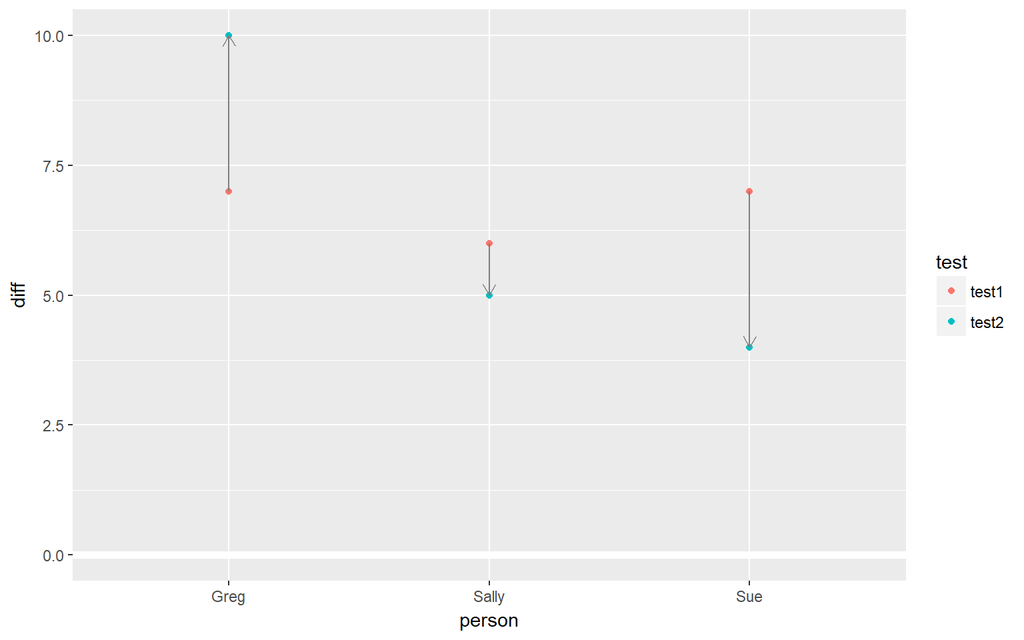

```r
scores <- dplyr::data_frame(
  person = rep(c("Greg", "Sally", "Sue"), each = 2),
  time = rep(c("pre", "post"), 3),
  test1 = round(rnorm(6, mean = 80, sd = 4), 0),
  test2 = round(jitter(test1, 15), 0)
)
scores_1 <- gather(scores, key = test, value = score, 3:4)
scores_2 <- spread(scores_1, key = time, value = score)
scores_3 <- mutate(scores_2, diff = post - pre)

ggplot(scores_3, aes(person, diff, colour = test)) +
  geom_hline(size = 2, colour = "white", yintercept = 0) +
  geom_point() +
  geom_path(aes(group = person), colour = "grey50",
            arrow = arrow(length = unit(0.25, "cm")))
```

# 6 Summary

- `convert = TRUE`와 `na.rm = TRUE`를 활용하자.
- `sprintf("x1.%02d", 1:10)`를 활용
- tidy data로 만든 후 분석하자.
- 시간의 전후 데이터는 차이를 시각화 해보자.

# 7 Chapter 10

> Data Transformation

# 8 Filter Observations

좋은 데이터 분석 방법은 하나의 관측 단위에 대해 다른 단위에 대해 결론을 일반화하도록 시도하기 전에 어떻게 작동하는지를 이해하는 것이다. 소규모의 집합에 집중하고 마스터해서 더 큰 집합에 집중하고 전체 데이터셋에 결론을 적용시키는 것이다.

필터링은 또한 이상치를 추출하는데 유용하다. 일반적으로 단순히 이상치를 버리는것을 원하지 않는다. 넓은 트랜드를 요약한다. 어떻게 진행되고있는지를 이해할 수 있다면 이상치를 보기위해 조사하자.

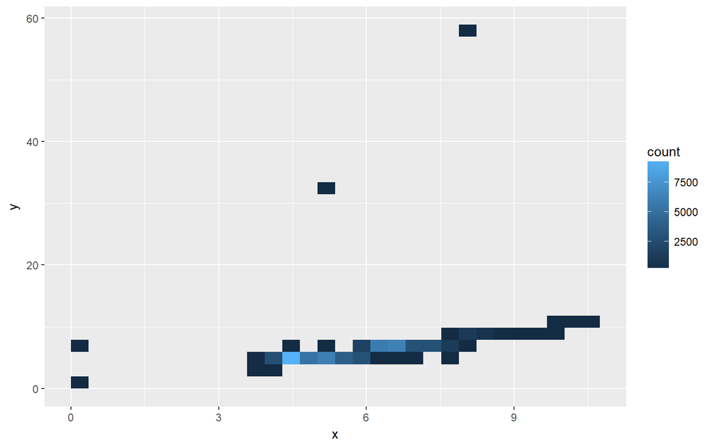

```r
ggplot(diamonds, aes(x, y)) +
  geom_bin2d()
```

```r
filter(diamonds, x == 0 | y == 0) # 이상치 확인
```

```
## # A tibble: 8 x 10
##   carat cut       color clarity depth table price     x     y     z
##   <dbl> <ord>     <ord> <ord>   <dbl> <dbl> <int> <dbl> <dbl> <dbl>
## 1  1.07 Ideal     F     SI2      61.6    56  4954     0  6.62     0
## 2  1    Very Good H     VS2      63.3    53  5139     0  0        0
## 3  1.14 Fair      G     VS1      57.5    67  6381     0  0        0
## 4  1.56 Ideal     G     VS2      62.2    54 12800     0  0        0
## 5  1.2  Premium   D     VVS1     62.1    59 15686     0  0        0
## 6  2.25 Premium   H     SI2      62.8    59 18034     0  0        0
## 7  0.71 Good      F     SI2      64.1    60  2130     0  0        0
## 8  0.71 Good      F     SI2      64.1    60  2130     0  0        0
```

실제 분석에서 데이터 품질 문제의 원인을 찾기위해 이상치의 세부사항을 들여다 본다. 이 경우에는 단순히 제거하고 나서 나머지것들을 보자.

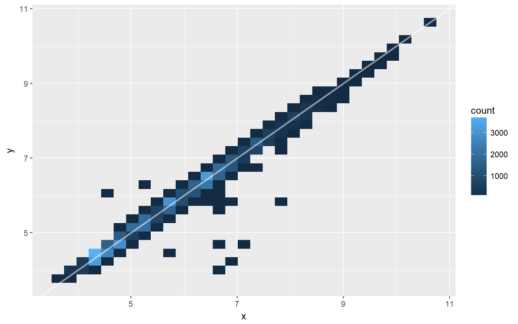

```r
diamonds_ok <- filter(diamonds, x > 0, y > 0, y < 20)
ggplot(diamonds_ok, aes(x, y)) +
  geom_bin2d() +
  geom_abline(slope = 1, colour = "white", size = 1, alpha = 0.5)
```

x, y의 강한 관계를 볼 수 있다. 참조 선을 추가했다. 하지만 이 플랏에는 여전히 문제가 있다.

- 이 플랏은 대부분 비어있다. 그 이유는 데이터의 대부분은 대각선을 따라 있다.
- 몇가지 이변량 이상치가 있지만 단순히 `filter`로는 찾기 힘들다.

## 8.1 Useful Tools

- `x %in% c("a", "b", "c")`: x is one of the values in the right hand side
- `x & y`: TRUE if both x and y are TRUE
- `x | y`: TRUE if either x or y (or both) are TRUE
- `xor(x, y)` : TRUE if either x or y are TRUE, but not both
- Size is between 1 and 2 carats : `floor(carat) == 1`
- An average dimension greater than 3 : (x + y + z) / 3 > 3

좀 더 복잡해지면 새로운 변수를 만들자. 그러면 부분집합 하기 전에 계산을 제대로 했는지 확인 할 수 있다.

## 8.2 Missing Values

결측치를 찾는 데에는 `is.na(x)`를 사용하라.

## 8.3 Exercises

1. Practice your filtering skills by: • A carat smaller than the median carat.

```r
diamonds %>%
  filter(carat < median(carat))
```

• Cost more than $10,000 per carat

```r
diamonds %>%
  filter(price > 10000 & floor(carat))
```

```
## # A tibble: 5,222 x 10
##    carat cut       color clarity depth table price     x     y     z
##    <dbl> <ord>     <ord> <ord>   <dbl> <dbl> <int> <dbl> <dbl> <dbl>
##  1  1.7  Ideal     J     VS2      60.5    58 10002  7.73  7.74  4.68
##  2  1.03 Ideal     E     VVS2     60.6    59 10003  6.5   6.53  3.95
##  3  1.23 Very Good G     VVS2     60.6    55 10004  6.93  7.02  4.23
##  4  1.25 Ideal     F     VS2      61.6    55 10006  6.93  6.96  4.28
##  5  2.01 Very Good I     SI2      61.4    63 10009  8.19  7.96  4.96
##  6  1.21 Very Good F     VS1      62.3    58 10009  6.76  6.85  4.24
##  7  1.51 Premium   I     VS2      59.9    60 10010  7.42  7.36  4.43
##  8  1.01 Fair      D     SI2      64.6    58 10011  6.25  6.2   4.02
##  9  1.05 Ideal     F     VVS2     60.5    55 10011  6.67  6.58  4.01
## 10  1.6  Ideal     J     VS1      62      53 10011  7.57  7.56  4.69
## # ... with 5,212 more rows
```

2. Repeat the analysis of outlying values with z. Compared to x and y, how would you characterise the relationship of x and z, or y and z?

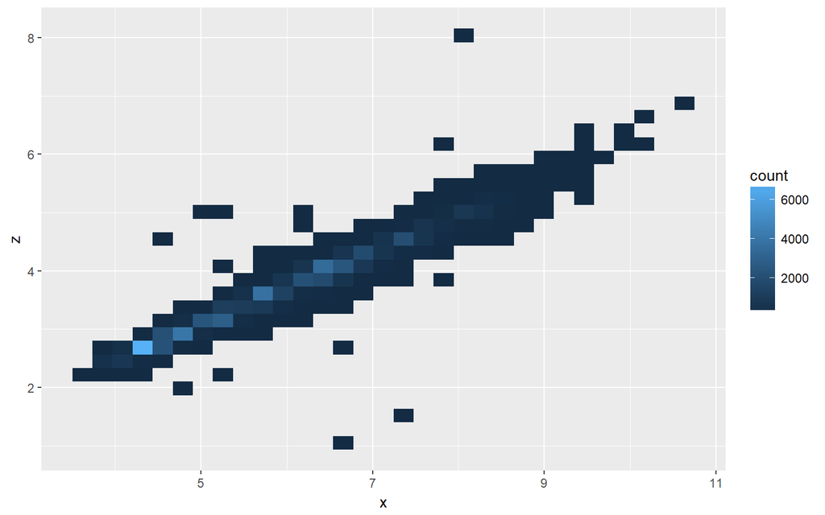

```r
temp <- diamonds %>%
  filter(x > 0 & z > 0 & z < 30)
ggplot(temp, aes(x, z)) +
  geom_bin2d()
```

3. Install the ggplot2movies package and look at the movies that have a missing budget. How are they different from the movies with a budget? (Hint: try a frequency polygon plus colour = is.na(budget).)

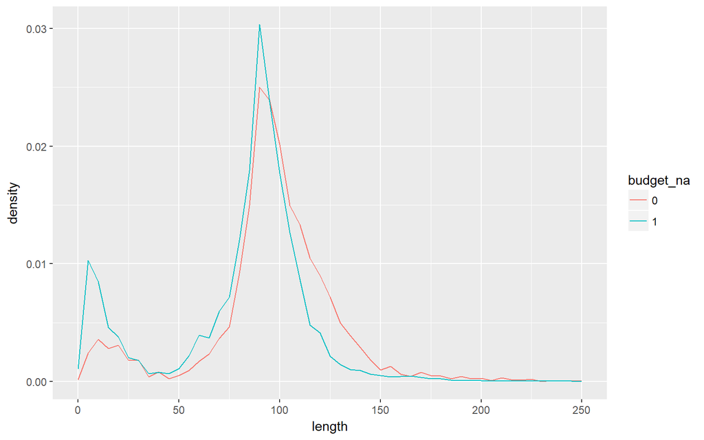

```r
library(ggplot2movies)
temp <- movies
temp <- mutate(temp, budget_na = as.factor(ifelse(is.na(budget), 1, 0)))

ggplot(temp, aes(length, colour = budget_na)) +
  geom_freqpoly(aes(y = ..density..), binwidth = 5) +
  xlim(0, 250)
```

이런식으로 다른 변수들도 확인

# 9 Create New Variables

x와 y의 관계를 더 잘 탐구하기 위해 데이터를 대각이 아닌 flat하도록 회전시키는것은 유용하다.

```r
diamonds_ok2 <- mutate(diamonds_ok,
  sym = x - y,
  size = sqrt(x ^ 2 + y ^ 2)
)
diamonds_ok2
```

```
## # A tibble: 53,930 x 12
##    carat cut      color clarity depth table price     x     y     z      sym
##    <dbl> <ord>    <ord> <ord>   <dbl> <dbl> <int> <dbl> <dbl> <dbl>    <dbl>
##  1 0.23  Ideal    E     SI2      61.5    55   326  3.95  3.98  2.43 -0.0300
##  2 0.21  Premium  E     SI1      59.8    61   326  3.89  3.84  2.31  0.05
##  3 0.23  Good     E     VS1      56.9    65   327  4.05  4.07  2.31 -0.02
##  4 0.290 Premium  I     VS2      62.4    58   334  4.2   4.23  2.63 -0.03
##  5 0.31  Good     J     SI2      63.3    58   335  4.34  4.35  2.75 -0.01000
##  6 0.24  Very Go~ J     VVS2     62.8    57   336  3.94  3.96  2.48 -0.02
##  7 0.24  Very Go~ I     VVS1     62.3    57   336  3.95  3.98  2.47 -0.0300
##  8 0.26  Very Go~ H     SI1      61.9    55   337  4.07  4.11  2.53 -0.04
##  9 0.22  Fair     E     VS2      65.1    61   337  3.87  3.78  2.49  0.09
## 10 0.23  Very Go~ H     VS1      59.4    61   338  4     4.05  2.39 -0.0500
## # ... with 53,920 more rows, and 1 more variable: size <dbl>
```

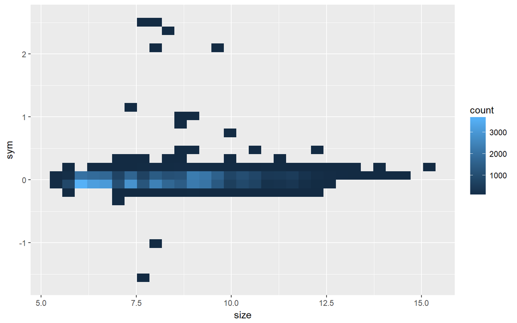

```r
ggplot(diamonds_ok2, aes(size, sym)) +
  stat_bin2d()
```

이 플랏은 두가지 이점을 가지고 있다: 대부분의 다이아로부터 패턴을 쉽게 볼 수 있고, 이상치를 쉽게 선택할 수 있다.

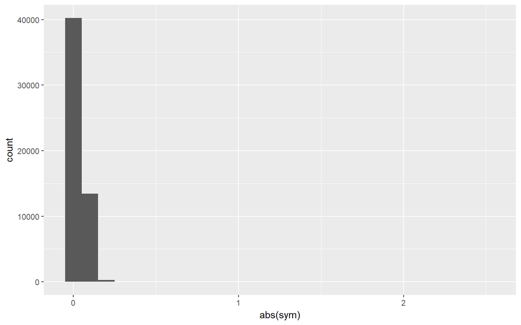

```r
ggplot(diamonds_ok2, aes(abs(sym))) +
  geom_histogram(binwidth = 0.10)
```

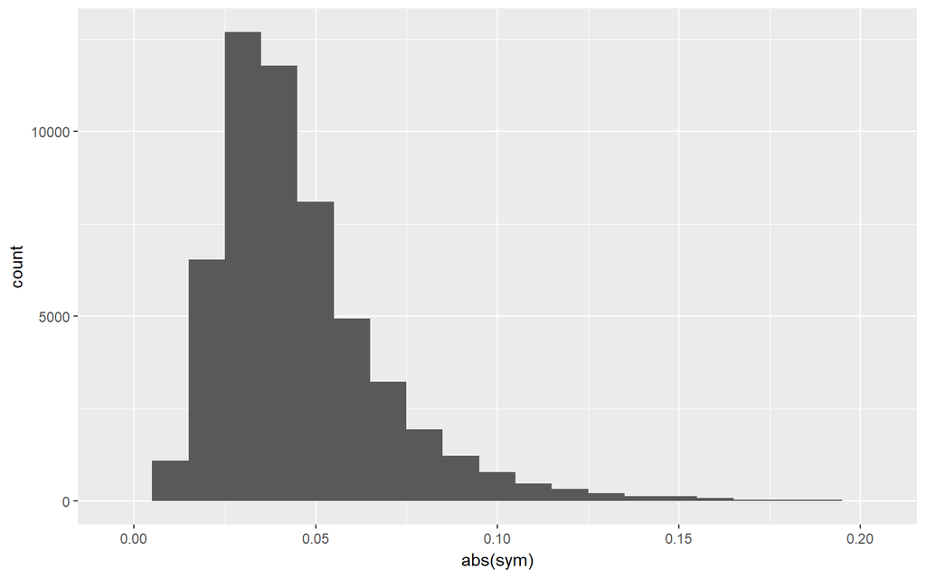

```r
diamonds_ok3 <- filter(diamonds_ok2, abs(sym) < 0.20)
ggplot(diamonds_ok3, aes(abs(sym))) +
  geom_histogram(binwidth = 0.01)
```

대부분의 다이아가 대칭에 가깝지만 완벽한 대칭은 거의 없음을 알 수 있다.

## 9.1 Useful Tools

일반적으로, 변환은 기본지식에 달려있다. 하지만 놀랍게도 넓은 범위의 상황에서 유용한 몇가지 변환이 있다.

- Log-transformations. 곱의 관계에 있는 것들을 합의 관계로 바꾸어준다. 즉 선형관계로 바꾸어준다. additive model : `Data = Seasonal effect + Trend + Cylical + Residual` Multiplicative model : `Data = Seasonal effect X Trend X Cylical X Residual -> log(Data) = log(Seasonal effect) + log(Trend) + log(Cyclical) + log(Residual)`

http://stats.stackexchange.com/questions/27951 를 참고하자

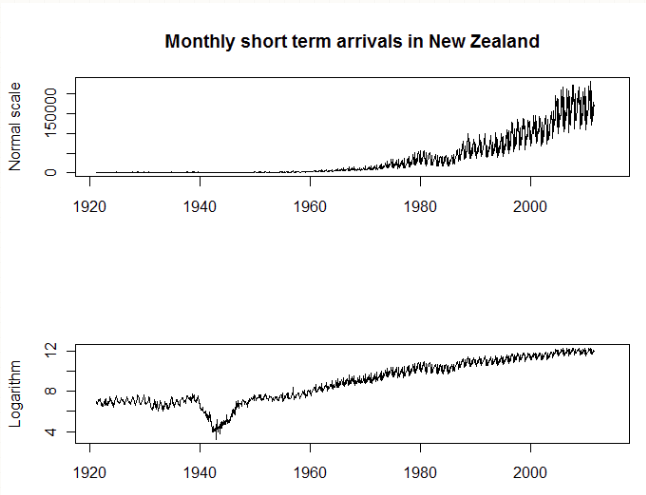

log를 취하기전에는 알 수 없었던 하락이 log를 취하면 알 수 있다. 세계2차대전때문에 감소한 것이다.

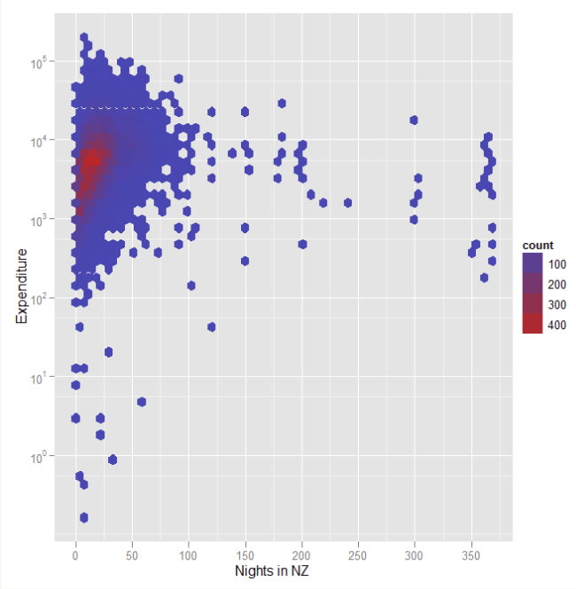

- Relative differnce : 두 변수간의 상대적 차이에 관심이 있다면, `log(x / y)` 를 사용하라. x / y 보다 좋은 이유는 대칭이기 때문이다. 만약 x < y이면, x / y는 [0, 1), 하지만 만약 x > y이면 x / y는 (1, Inf)이다.
- 때때로 적분하거나 미분하는것이 좀 더 해석하기 좋다. 만약 거리와 시간을 가지고 있다면 속도나 가속도가 좀 더 유용하거나 거꾸로 이거나. 적분은 데이터를 좀 더 매끄럽게 하고 미분은 덜 매끄럽게 한다.
- 수를 `abs(x) and sign(x)`로 규모와 방향으로 나누어라.
- 이전에 봤던 것 처럼 전반적인 크기와 차이를 나누는 것은 유용하다
- 강한 추세를 볼 수 있다면, 패턴과 잔차로 나누기 위해 모델링 하는것은 유용하다.
- 때때로 position을 극좌표로 바꾸는것은 유용하다(거꾸로하거나). distance (sqrt(x^2 + y^2)) and angle(atan2(y, x))

## 9.2 Exercises

1. Practice your variable creation skills by creating the following new variables: • The approximate volume of the diamond (using x, y, and z).

사각뿔 부피 + 사다리꼴(옆면) 부피하면 될 것 같다. 사각뿔은 depth 곱하기 z / 100이 높이고 가로 세로 x, y인 직사각형을 밑면으로 하는 사각뿔의 부피. 사다리꼴부피는 table width = table 곱하기 x / 100임을 이용해 구한다.

• The approximate density of the diamond.

1캐럿이 0.2g이므로 carat / volume

• The price per carat.

price / carat

• Log transformation of carat and price.

log(carat) log(price)

2. How can you improve the data density of ggplot(diamonds, aes(x, z)) + stat bin2d(). What transformation makes it easier to extract outliers?

우선 x = 0 , z = 0은 제거하자.

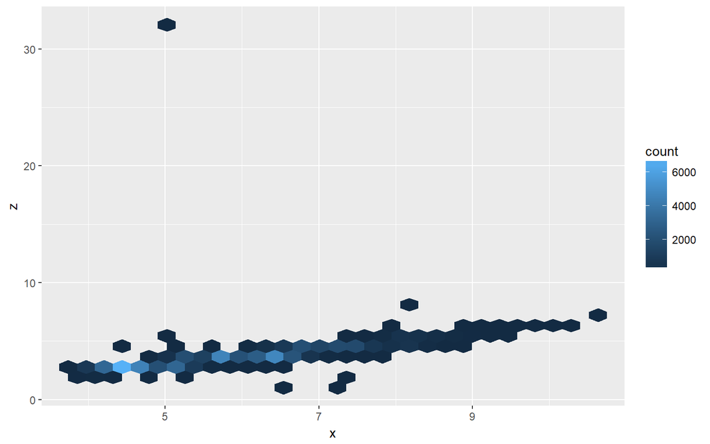

```r
temp <- filter(diamonds, x > 0 & z > 0)
ggplot(temp, aes(x, z)) +
  stat_binhex()
```

```r
library(car)
model <- lm(z ~ x, data = temp)
summary(model)
```

```
##
## Call:
## lm(formula = z ~ x, data = temp)
##
## Residuals:
##     Min      1Q  Median      3Q     Max
## -3.0963 -0.0398  0.0047  0.0447 28.6344
##
## Coefficients:
##              Estimate Std. Error  t value Pr(>|t|)
## (Intercept) 0.0313385  0.0034770    9.013   <2e-16 ***
## x           0.6121661  0.0005954 1028.197   <2e-16 ***
## ---
## Signif. codes:  0 '***' 0.001 '**' 0.01 '*' 0.05 '.' 0.1 ' ' 1
##
## Residual standard error: 0.1548 on 53918 degrees of freedom
## Multiple R-squared:  0.9515, Adjusted R-squared:  0.9515
## F-statistic: 1.057e+06 on 1 and 53918 DF,  p-value: < 2.2e-16
```

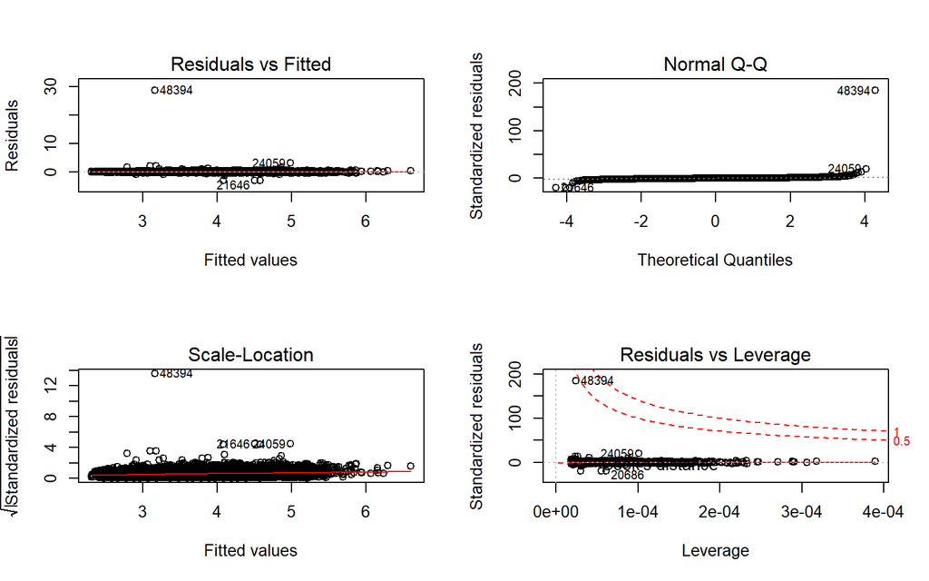

```r
par(mfrow = c(2,2))
plot(model)
```

log를 취하자

```r
model <- update(model, log(z) ~ log(x))
summary(model)
```

```
##
## Call:
## lm(formula = log(z) ~ log(x), data = temp)
##
## Residuals:
##      Min       1Q   Median       3Q      Max
## -1.33922 -0.01141  0.00194  0.01309  2.30762
##
## Coefficients:
##               Estimate Std. Error t value Pr(>|t|)
## (Intercept) -0.4691850  0.0010598  -442.7   <2e-16 ***
## log(x)       0.9925738  0.0006098  1627.8   <2e-16 ***
## ---
## Signif. codes:  0 '***' 0.001 '**' 0.01 '*' 0.05 '.' 0.1 ' ' 1
##
## Residual standard error: 0.02743 on 53918 degrees of freedom
## Multiple R-squared:  0.9801, Adjusted R-squared:  0.9801
## F-statistic: 2.65e+06 on 1 and 53918 DF,  p-value: < 2.2e-16
```

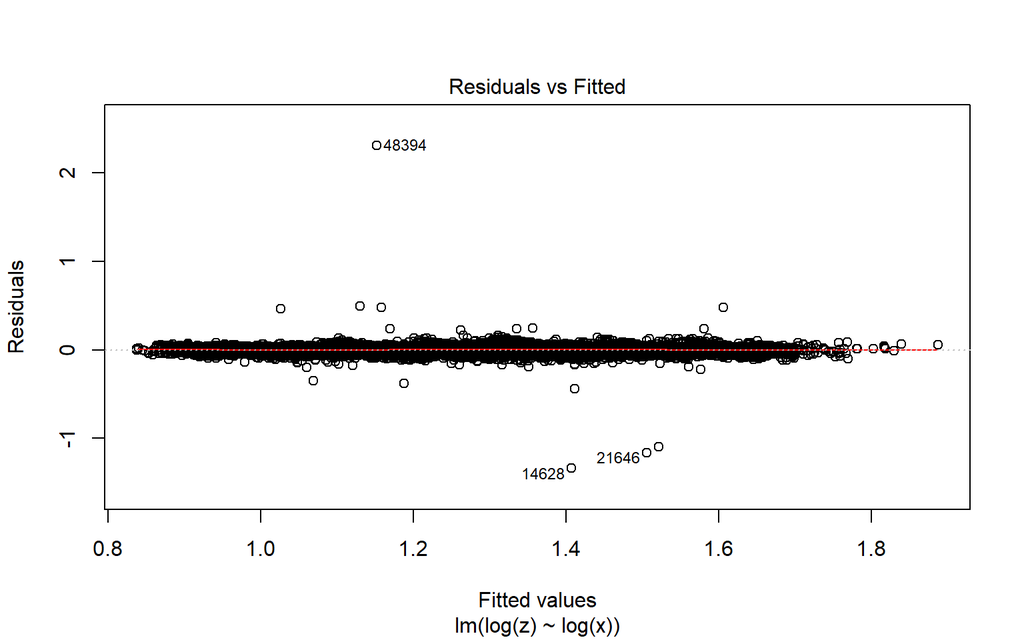

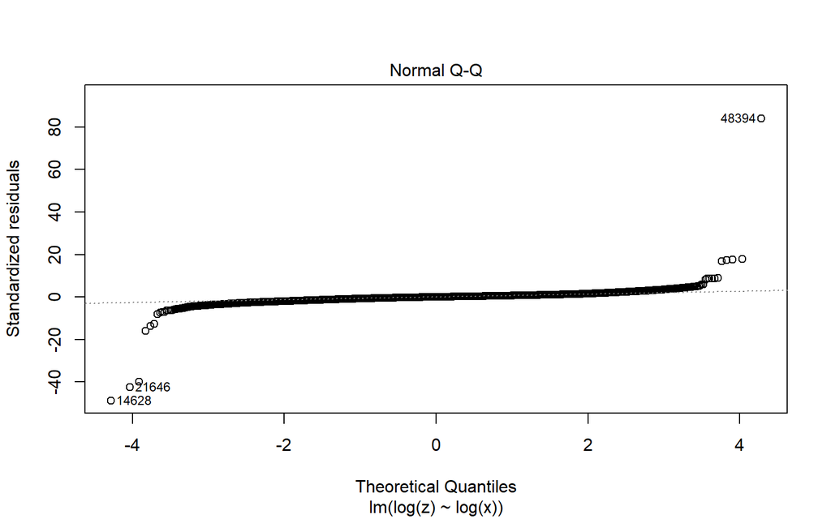

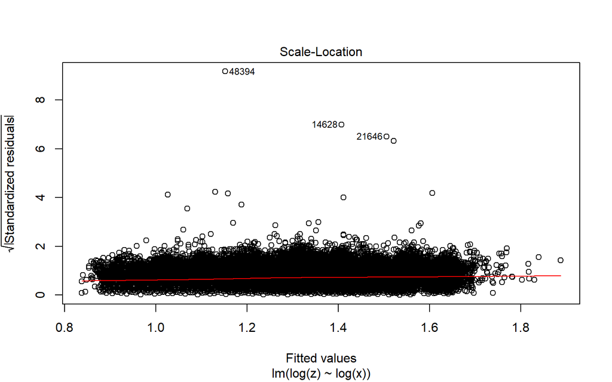

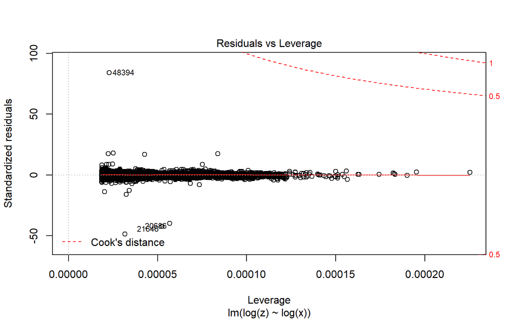

```r
plot(model)
```

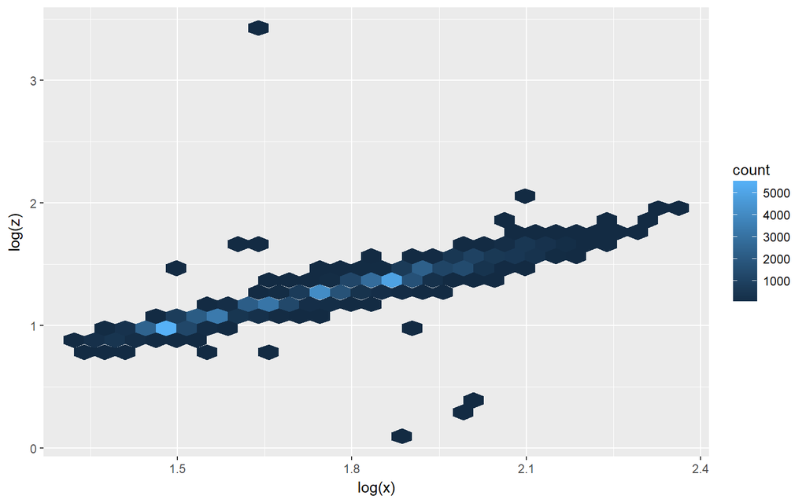

```r
ggplot(temp, aes(log(x), log(z))) +
  stat_binhex()
```

```r
outlierTest(model)
```

```
##        rstudent unadjusted p-value Bonferonni p
## 14628 -49.94746         0.0000e+00   0.0000e+00
## 20686 -40.57509         0.0000e+00   0.0000e+00
## 21646 -43.08113         0.0000e+00   0.0000e+00
## 48394  90.27568         0.0000e+00   0.0000e+00
## 49887  17.95928         6.5839e-72   3.5501e-67
## 24059  17.58877         4.6864e-69   2.5269e-64
## 49173  17.38667         1.5922e-67   8.5854e-63
## 34266  16.99033         1.4269e-64   7.6940e-60
## 33086 -16.10315         3.3159e-58   1.7879e-53
## 47122 -13.77312         4.3766e-43   2.3599e-38
```

4. Compare the distribution of symmetry for diamonds with x > y vs. x < y.

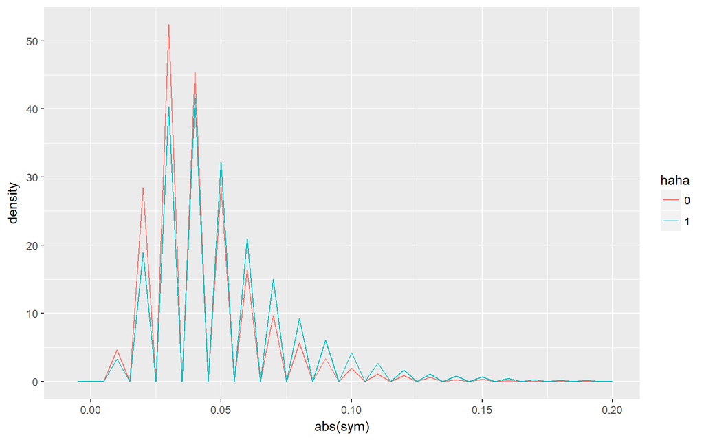

```r
diamonds_ok2$haha <- as.factor(ifelse(diamonds_ok2$x > diamonds_ok2$y,1, 0))
ggplot(diamonds_ok2, aes(abs(sym), y = ..density.., colour = haha)) +
  geom_freqpoly(binwidth = 0.005) +
  xlim(NA, 0.2)
```

도수 다각형은 범주의 레벨간에 걸쳐 분포를 비교할 때 적합하다. geom_density()의 사용은 3장을 참고하라. geom_freqpoly()의 사용은 5장을 참고하라.

# 10 Group_wise Summaries

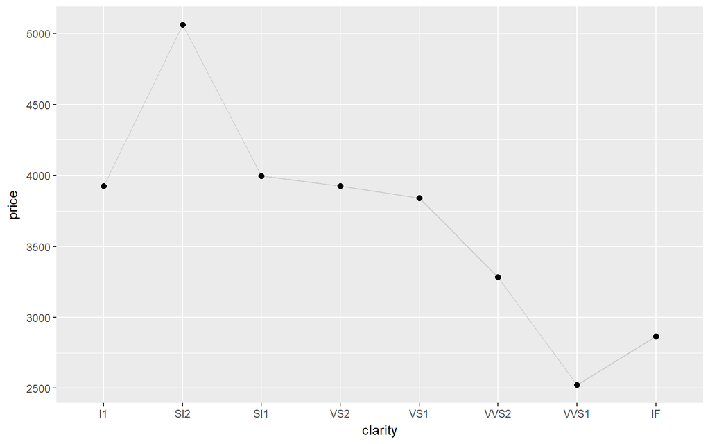

```r
sum_clarity <- diamonds %>%
  group_by(clarity) %>%
  summarise(price = mean(price))
ggplot(sum_clarity, aes(clarity, price)) +
  geom_line(aes(group = 1), colour = "grey80") +  # 주의하자
  geom_point(size = 2)
```

품질이 좋은게 더 싼 것 같다. 이상하다.

```r
cut_depth <- diamonds %>%
  group_by(cut, depth) %>%
  summarise(n = n()) %>%
  filter(depth > 55, depth < 70)
cut_depth
```

```
## # A tibble: 455 x 3
## # Groups:   cut [5]
##    cut   depth     n
##    <ord> <dbl> <int>
##  1 Fair   55.1     3
##  2 Fair   55.2     6
##  3 Fair   55.3     5
##  4 Fair   55.4     2
##  5 Fair   55.5     3
##  6 Fair   55.6     4
##  7 Fair   55.8     7
##  8 Fair   55.9     9
##  9 Fair   56       5
## 10 Fair   56.1     5
## # ... with 445 more rows
```

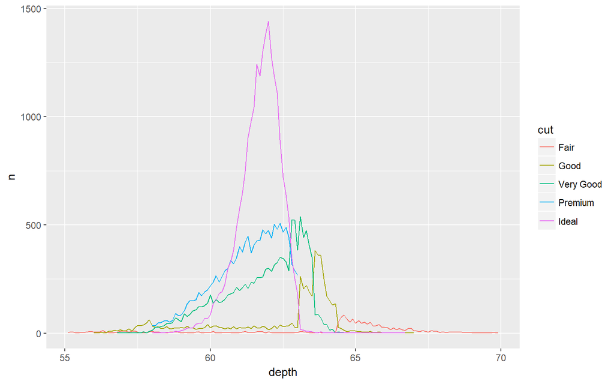

```r
ggplot(cut_depth, aes(depth, n, colour = cut)) +
  geom_line()
```

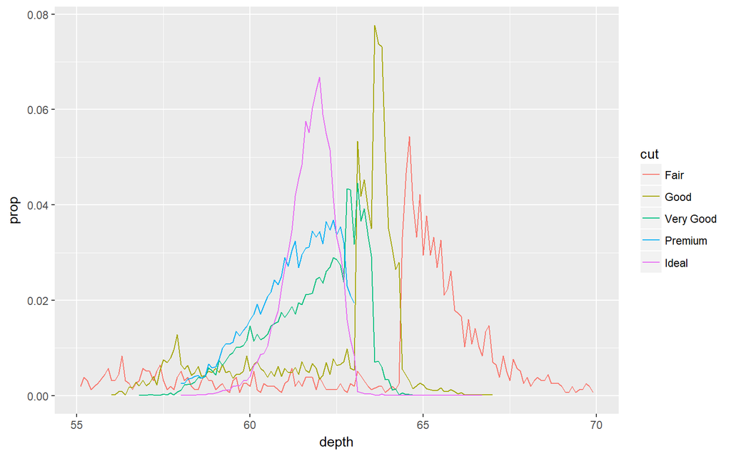

```r
cut_depth <- mutate(cut_depth, prop = n / sum(n))
ggplot(cut_depth, aes(depth, prop, colour = cut)) +
  geom_line()
```

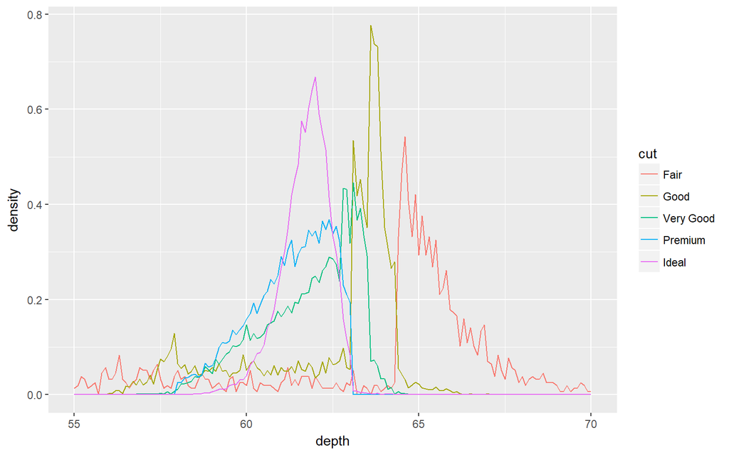

```r
ggplot(diamonds, aes(depth, colour = cut)) +
  geom_freqpoly(aes(y = ..density..), binwidth = 0.1) +
  xlim(55, 70)
```

추가적으로 geom_line이나 geom_freqpoly나 여기서는 거의 비슷. geom_freqpoly가 binwidth를 조절할 수 있으며 새로운 데이터를 만들지 않아도 되므로 geom_freqpoly가 더 좋아 보인다.

## 10.1 Useful Tools

- Counts : n(), n_distinct(x)
- Middle : mean(x), median(x)
- Spread : sd(x), mad(x), IQR(x) 여기서 mad는 median absolute deviation
- Extremes : quantile(x), min(x), max(x)
- Positions : first(x), last(x), nth(x, 2)

논리형 벡터와 sum(), mean()을 함께 사용해보자